# MovieLens Project Report

###### *REGULARIZED LINEAR BASELINE*

The USER and MOVIE effect variables in the baseline model were further improved by adding a regularization term to penalize estimate ratings with large variability that affected the best (and worst) rankings of obscure movies, i.e. users or movies that had few ratings of high and/or low values. As the penalty term lambda increases, the estimate shrinks toward the mean and thus allows a better representation of the true value.

```r
# Set overall average rating
overall <- mean(train_edx$rating)

# Regularization function for lambda
regulizer <- function(lambda, training, testing){
  # Define predictors:
  bu <- training %>%
    group_by(userId) %>%
    summarize(bu = sum(rating - overall)/(n() + lambda))
  bi <- training %>%
    left_join(bu, by = "userId") %>%
    group_by(movieId) %>%
    summarize(bi = sum(rating - bu - overall)/(n() + lambda))
  # Predict ratings:
  preds <- testing %>%
    left_join(bu, by = "userId") %>%
    left_join(bi, by = "movieId") %>%
    mutate(pred = overall + bu + bi) %>%
    pull(pred)
  return(RMSE(preds, testing$rating))
}
```

Lambda was selected and tuned by minimizing the RMSE.

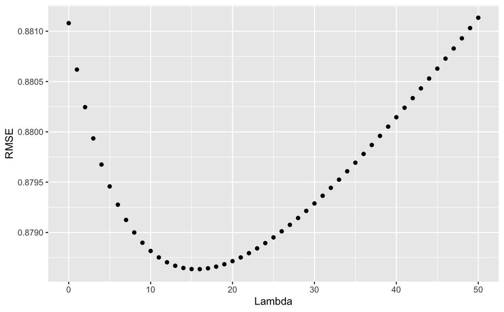

Next, lambda was applied to the baseline model, which improved the model RMSE nearly to the target for the project.

```r
# Update baseline model with regularized USER and MOVIE effect, leave out GENRE negligible impact
bu <- train_edx %>%
  group_by(userId) %>%
  summarize(bu = sum(rating - overall)/(n() + lambda))
bi <- train_edx %>%
  left_join(bu, by = "userId") %>%
  group_by(movieId) %>%
  summarize(bi = sum(rating - bu - overall)/(n() + lambda))
# Predict ratings:
pred_bu_bi_reg <- test_edx %>%
  left_join(bu, by = "userId") %>%
  left_join(bi, by = "movieId") %>%
  mutate(pred = overall + bu + bi) %>%
  pull(pred)
baseline_reg_rmse <- RMSE(test_edx$rating, pred_bu_bi_reg)
```

###### *MATRIX FACTORIZATION MODEL*

The winners of the Netflix Prize utilized matrix factorization in the winning model ([Koren 2009](https://www2.seas.gwu.edu/~simhaweb/champalg/cf/papers/KorenBellKor2009.pdf)). Matrix factorization is a machine learning tool used widely in user-item recommender systems like the ones used by Netflix, Amazon, etc. Interactions between the users and items (in our case movies) are arranged into a matrix with rows of users and columns of items. The values in our matrix were the ratings, and the algorithm attempts to fill in the missing values. This was very useful in working with the large data set in this project.

The `recosystem` package was utilized to solve this matrix. It uses parallel matrix factorization. Briefly, `recosystem` takes an input data set, creates a model object, trains the model, and predicts the output. A detailed description can be found in the package [vignette](https://cran.r-project.org/web/packages/recosystem/vignettes/introduction.html).

```r
# Convert the train and test data sets into input format for recosystem
set.seed(50)
train_rec <- with(train_edx, data_memory(user_index = userId,
                                         item_index = movieId,
                                         rating = rating))
test_rec <- with(test_edx, data_memory(user_index = userId,
                                       item_index = movieId,
                                       rating = rating))

# Assign the RecoSys object model:
rec <- recosystem::Reco()
```

```r
# Train the model with default tuning parameters
mat_fit <- rec$train(train_rec)
```

```
iter      tr_rmse          obj
   0       0.9624   1.3279e+07
   1       0.8810   1.2028e+07
   2       0.8579   1.1796e+07
   3       0.8462   1.1660e+07
   4       0.8408   1.1605e+07
   5       0.8366   1.1574e+07
   6       0.8328   1.1542e+07
   7       0.8298   1.1515e+07
   8       0.8275   1.1500e+07
   9       0.8259   1.1486e+07
  10       0.8245   1.1472e+07
  11       0.8236   1.1467e+07
  12       0.8227   1.1459e+07
  13       0.8222   1.1452e+07
  14       0.8216   1.1451e+07
  15       0.8211   1.1443e+07
  16       0.8208   1.1440e+07
  17       0.8204   1.1435e+07
  18       0.8202   1.1439e+07
  19       0.8198   1.1430e+07
```

```r
# Predict the ratings for the test set with the matrix factorization model
pred_matrix <- rec$predict(test_rec, out_memory())
```

```r
# Calculate the RMSE
matrix_fact_rmse <- RMSE(test_edx$rating, pred_matrix)
```

The matrix factorization model was applied to the training data and decreased the RMSE to below the target for the project.

## 3. Results

The results of the modeling experiments above are as follows:

| Model | RMSE |
| --- | --- |
| Project Target | < 0.86490 |
| Just the Average | 1.05932678421876 |
| User Effect | 0.976941239555826 |
| Baseline Model - User + Movie Effects | 0.881080357030548 |
| Baseline + Genre | 0.903852665156232 |
| Regularized Baseline - User and Movie | 0.878635643659205 |
| Matrix Factorization - User + Movie | 0.832535692022657 |

We can see that the baseline model that included the USER and MOVIE effects had an RMSE of `0.8810804`.

As mentioned above, when a linear model was applied to the GENRE term an increase in the RMSE over the baseline was noted. The new RMSE was `0.9038527`. This model potentially could be included as part of an ensemble or developed further, but for the purposes of this project was left out of the final model.

We were able to make subsequent improvements to the model by regularizing the baseline linear model for the USER and MOVIE terms and by applying a matrix factorization model, RMSEs `0.8786356` and `0.8325357` respectively.

In the matrix factorization model, the observed RMSE was `0.8325357`, which surpassed the target `< 0.86490`. The matricized method allows a rating to be decomposed into latent factors that are detected and learned by the algorithm ([Chen](http://blog.echen.me/2011/10/24/winning-the-netflix-prize-a-summary/)). These latent factors can be thought of as categories like “blockbuster” or “sci-fi” or “Tom Cruise Movies” that are not readily discernible from the variables in the data set but that a computer can calculate the respective correlations based on the matrix of ratings data presented.

###### *FINAL HOLDOUT TESTING AND FINAL RMSE*

The matrix factorization model was selected for use in the final holdout testing as this model beat the target RMSE in development. The regularized baseline model was also run against the final holdout test set for comparison to the matrix model, but the final reportable RMSE was calculated using the matrix model.

| Model | RMSE |
| --- | --- |
| Project Target | < 0.86490 |
| Final Regularized Baseline | 0.879743425714982 |
| Final Matrix Factorization | 0.83326685106195 |

The final RMSE was calculated to be `0.8332669` from the parallel matrix factorization model. We can see that this model beats the target and the RMSEs of the previous models. The next closest model was the regularized linear baseline model, shown above for comparison.

## 4. Conclusion

The objective of this project was to develop an algorithm for predicting movie ratings from the MovieLens 10M data set using R. Several techniques were utilized to achieve this purpose including data import and cleaning, data exploration, modeling, etc.

Once the data were explored and visualized, a linear baseline model was developed capturing USER and MOVIE effects. This model was improved upon using regularization, and a parallel matrix factorization model was developed.

The **final reportable RMSE of the project was `0.8332669`**, from evaluating the final holdout data with the matrix factorization model.

###### *FUTURE STUDIES*

The project goal was achieved using only two predictors, USER and MOVIE effects. There are many other possible predictors that might still be explored in order to further improve upon the final model’s RMSE. These may be related to movie genres or temporal effects that can be elucidated with further study.

Additionally, the Netflix Prize winners documented their use of gradient boosted decision trees (GBDTs) and advanced model blending techniques.

Future work should be centered around these ideas.